# Manual de Análisis de Desigualdad de Ingresos en R

Héctor Nájera

2025-02-23

Introducción

Este manual proporciona una guía paso a paso para el análisis de la distribución del ingreso y su desigualdad en R.

# 1 Los paquetes necesarios son:

```r
library(pacman)
p_load(VGAM, dplyr, survey, ineq, dineq, DescTools, ggplot2, kableExtra, tidyr, boot)
```

# 2 Inspección de los datos

```r
load("data")
names(data)
```

```
## [1] "household_id"      "household_income"  "IngLaboral"
## [4] "IngRemesas"        "Programas"         "income_check"
## [7] "Education"         "per_capita_income" "survey_weight"
```

```r
head(data)
```

```
##   household_id household_income IngLaboral IngRemesas Programas income_check
## 1            1         4989.705  3742.2791   498.9705  748.4558     4989.705
## 2            2        15879.815 11909.8613  1587.9815 2381.9723    15879.815
## 3            3         6799.716  5099.7868   679.9716 1019.9574     6799.716
## 4            4        21713.559 16285.1690  2171.3559 3257.0338    21713.559
## 5            5        29670.636 26703.5721  1483.5318 1483.5318    29670.636
## 6            6         1299.571   974.6785   129.9571  194.9357     1299.571
##   Education per_capita_income survey_weight
## 1       Low         4989.7055      2.067390
## 2      High         5293.2717      2.572616
## 3    Medium         6799.7158      2.078093
## 4      High         7237.8529      2.482787
## 5      High        14835.3178      2.252531
## 6       Low          649.7857      1.773495
```

# 3 Visualización de la Distribución del Ingreso

Antes de calcular los deciles, observemos la distribución del ingreso mediante gráficos de densidad ponderados y no ponderados:

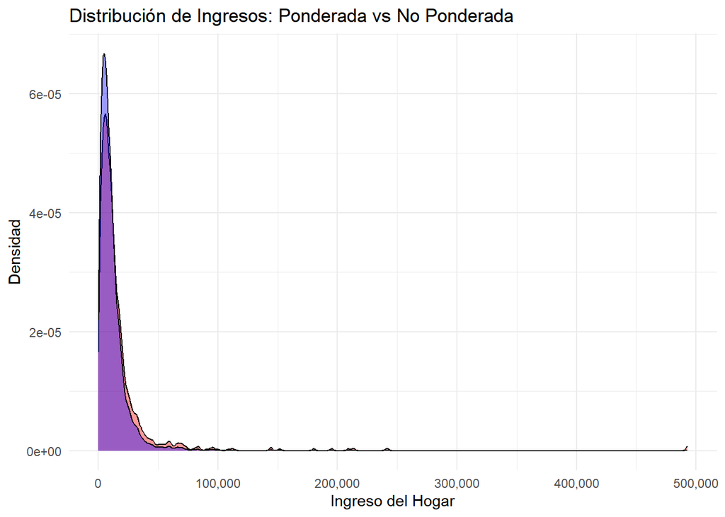

```r
ggplot(data, aes(x = household_income)) +
  geom_density(aes(y = ..density.., weight = survey_weight), fill = "red", alpha = 0.4) +
  geom_density(aes(y = ..density..), fill = "blue", alpha = 0.4) +
  scale_x_continuous(labels = scales::comma) +
  labs(title = "Distribución de Ingresos: Ponderada vs No Ponderada",
       x = "Ingreso del Hogar", y = "Densidad") +
  theme_minimal() +
  scale_fill_manual(values = c("blue", "red")) +
  theme(legend.position = "bottom")
```

> Nota: hacer ingreso per cápita y pensar en las diferencias

## 3.1 Diagramas de caja

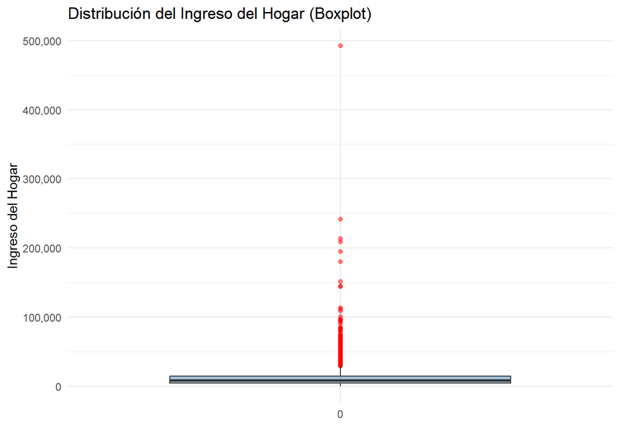

```r
ggplot(data, aes(x = factor(0), y = household_income)) +
  geom_boxplot(fill = "steelblue", alpha = 0.5, outlier.colour = "red") +
  scale_y_continuous(labels = scales::comma) +
  labs(title = "Distribución del Ingreso del Hogar (Boxplot)",
       x = "", y = "Ingreso del Hogar") +
  theme_minimal()
```

# 4 Cálculo a mano y con paquetería de los Deciles de ingreso

Para calcular los deciles de ingreso por hogar y per cápita de manera manual:

```r
data <- data %>%
  mutate(
    household_decile = ntile(household_income, 10),
    per_capita_decile = ntile(per_capita_income, 10)
  )

head(data)
```

```
##   household_id household_income IngLaboral IngRemesas Programas income_check
## 1            1         4989.705  3742.2791   498.9705  748.4558     4989.705
## 2            2        15879.815 11909.8613  1587.9815 2381.9723    15879.815
## 3            3         6799.716  5099.7868   679.9716 1019.9574     6799.716
## 4            4        21713.559 16285.1690  2171.3559 3257.0338    21713.559
## 5            5        29670.636 26703.5721  1483.5318 1483.5318    29670.636
## 6            6         1299.571   974.6785   129.9571  194.9357     1299.571
##   Education per_capita_income survey_weight household_decile per_capita_decile
## 1       Low         4989.7055      2.067390                3                 7
## 2      High         5293.2717      2.572616                8                 8
## 3    Medium         6799.7158      2.078093                5                 8
## 4      High         7237.8529      2.482787                9                 8
## 5      High        14835.3178      2.252531               10                10
## 6       Low          649.7857      1.773495                1                 1
```

Ahora, utilizamos el paquete `statar` para calcular los deciles con pesos (cálculo de percentiles exactos):

```r
data <- data %>%
  mutate(
    household_decile_statar = statar::xtile(household_income, w = survey_weight, n = 10),
    per_capita_decile_statar = statar::xtile(per_capita_income, w = survey_weight, n = 10)
  )
```

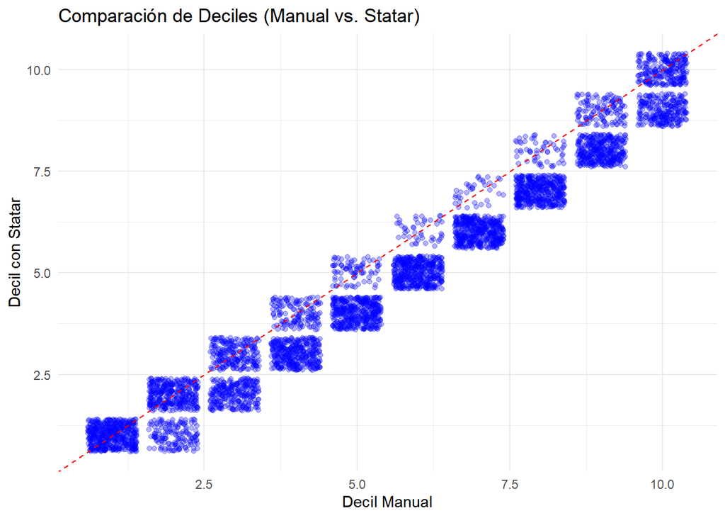

```r
data <- data %>%
  mutate(decile_shift = household_decile_statar - household_decile)  # Difference

ggplot(data, aes(x = household_decile, y = household_decile_statar)) +
  geom_jitter(alpha = 0.3, color = "blue") +  # Add jitter to avoid overplotting
  geom_abline(slope = 1, intercept = 0, linetype = "dashed", color = "red") +
  labs(title = "Comparación de Deciles (Manual vs. Statar)",
       x = "Decil Manual",
       y = "Decil con Statar") +
  theme_minimal()
```

# 5 Comparación del ingreso per cápita vs el del hogar

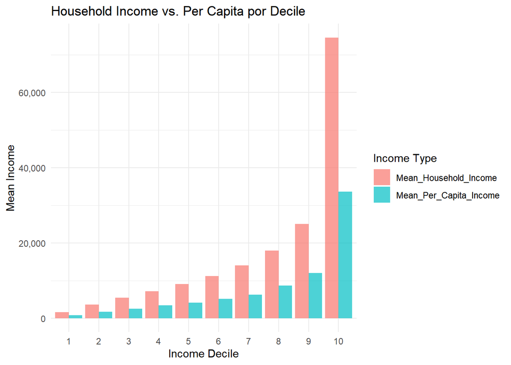

```r
income_means <- data %>%
  group_by(household_decile_statar) %>%
  summarise(
    Mean_Household_Income = weighted.mean(household_income, survey_weight, na.rm = TRUE),
    Mean_Per_Capita_Income = weighted.mean(per_capita_income, survey_weight, na.rm = TRUE)
  )


income_means_long <- income_means %>%
  pivot_longer(cols = c(Mean_Household_Income, Mean_Per_Capita_Income),
               names_to = "Income_Type", values_to = "Mean_Income")


ggplot(income_means_long, aes(x = factor(household_decile_statar), y = Mean_Income, fill = Income_Type)) +
  geom_col(position = "dodge", alpha = 0.7) +
  scale_y_continuous(labels = scales::comma) +
  labs(title = "Household Income vs. Per Capita por Decile",
       x = "Income Decile", y = "Mean Income",
       fill = "Income Type") +
  theme_minimal()
```

# 6 Medidas de Desigualdad: GINI y Theil

Para calcular los índices de Gini y Theil con pesos se utilizan paquetes distintos `DescTools` en el caso del Gini y `dineq` para Theil.

```r
gini_index <- Gini(data$household_income, weights = data$survey_weight)
theil_index <- theil.wtd(x = data$household_income, weights = data$survey_weight)

gini_index_unweighted <- Gini(data$household_income)
theil_index_unweighted <- theil.wtd(x = data$household_income)  # No weights used

gini_index
```

```
## [1] 0.5475329
```

```r
theil_index
```

```
## [1] 0.6613971
```

```r
gini_index_unweighted
```

```
## [1] 0.4696448
```

```r
theil_index_unweighted
```

```
## [1] 0.4203841
```

> Nota: ¿Por qué Theil es más sensible?

# 7 Evaluación del Impacto de una Observación Extrema sobre Gini y Theil

Para evaluar el impacto de una observación con un ingreso tres veces mayor al valor más alto en la distribución original, añadimos un caso extremo (objeto `data_extreme`) y recalculamos los índices de desigualdad:

Se crea un hogar ficticio con un ingreso 3 veces mayor que el hogar más rico original y se le asigna un peso muestral de 1 para evaluar su impacto en la desigualdad.

```r
max_income <- max(data$household_income)

data_extreme <- data %>%
  bind_rows(data.frame(
    household_id = n + 1,
    household_income = 3 * max_income,
    household_size = 1,
    per_capita_income = 3 * max_income,
    survey_weight = 1
  ))


gini_before <- Gini(data$household_income, weights = data$survey_weight)
theil_before <- theil.wtd(x = data$household_income, weights = data$survey_weight)


gini_after <- Gini(data_extreme$household_income, weights = data_extreme$survey_weight)
theil_after <- theil.wtd(x = data_extreme$household_income, weights = data_extreme$survey_weight)


gini_relative_change <- ((gini_after - gini_before) / gini_before) * 100
theil_relative_change <- ((theil_after - theil_before) / theil_before) * 100


impact_analysis <- data.frame(
  Metric = c("Gini", "Theil"),
  Before = c(gini_before, theil_before),
  After = c(gini_after, theil_after),
  Absolute_Change = c(gini_after - gini_before, theil_after - theil_before),
  Relative_Change_Percentage = c(gini_relative_change, theil_relative_change)
)

print(impact_analysis)
```

```
##   Metric    Before     After Absolute_Change Relative_Change_Percentage
## 1   Gini 0.5475329 0.5519112     0.004378364                  0.7996532
## 2  Theil 0.6613971 0.6897400     0.028342839                  4.2852981
```

# 8 Diferencias en Inferencias Según los Deciles Utilizados

Para analizar cómo la selección de diferentes deciles influye en la inferencia sobre la desigualdad:

- Comparación entre el percentil 90 y la mediana
- Comparación entre el percentil 99 y el percentil 50
- Comparación entre el percentil 99.9 y el percentil 50

```r
p90_p50 <- quantile(data$household_income, 0.9) / quantile(data$household_income, 0.5)
p99_p50 <- quantile(data$household_income, 0.99) / quantile(data$household_income, 0.5)
p999_p50 <- quantile(data$household_income, 0.999) / quantile(data$household_income, 0.5)

list(
  Ratio_90_50 = p90_p50,
  Ratio_99_50 = p99_p50,
  Ratio_999_50 = p999_p50
)
```

```
## $Ratio_90_50
##      90%
## 2.761779
##
## $Ratio_99_50
##      99%
## 7.857678
##
## $Ratio_999_50
##    99.9%
## 21.79762
```

# 9 Descomposición de Desigualdad usando Gini y Theil

Podemos descomponer la desigualdad total en componentes basados en **fuentes de ingreso** (`IngLaboral`, `IngRemesas`, `Programas`) utilizando los índices de **Gini y Theil**.

```r
gini_total <- Gini(data$household_income, weights = data$survey_weight)
theil_total <- theil.wtd(x = data$household_income, weights = data$survey_weight)

gini_laboral <- Gini(data$IngLaboral, weights = data$survey_weight)
gini_remesas <- Gini(data$IngRemesas, weights = data$survey_weight)
gini_programas <- Gini(data$Programas, weights = data$survey_weight)

theil_laboral <- theil.wtd(x = data$IngLaboral, weights = data$survey_weight)
theil_remesas <- theil.wtd(x = data$IngRemesas, weights = data$survey_weight)
theil_programas <- theil.wtd(x = data$Programas, weights = data$survey_weight)

decomposition_results <- data.frame(
  Component = c("Total", "IngLaboral", "IngRemesas", "Programas"),
  Gini = c(gini_total, gini_laboral, gini_remesas, gini_programas),
  Theil = c(theil_total, theil_laboral, theil_remesas, theil_programas)
)

decomposition_results
```

```
##    Component      Gini     Theil
## 1      Total 0.5475329 0.6613971
## 2 IngLaboral 0.5822715 0.7531072
## 3 IngRemesas 0.4253761 0.3854221
## 4  Programas 0.3816748 0.2896707
```

### 9.0.1 **Interpretación**

- El **Gini total** muestra la desigualdad de todo el ingreso, mientras que el **Gini de cada fuente** mide su contribución individual.
- El **Theil total** puede ser descompuesto en sus fuentes para evaluar su impacto en la desigualdad.
- **Si un componente tiene un Gini o Theil alto**, significa que contribuye **más a la desigualdad general**.

Esta descomposición permite analizar qué fuentes de ingreso explican más la desigualdad y qué políticas podrían ser implementadas para reducirla.

# 10 Descomposición por fuente

Este código utiliza la función `gini_decomp_source()` del paquete `GiniDecompLY` para descomponer la desigualdad (medida por el Índice de Gini) según diferentes fuentes de ingreso.

data → Es el conjunto de datos con la información de ingresos. IngLaboral → Ingresos laborales. IngRemesas → Ingresos provenientes de remesas. Programas → Transferencias de programas sociales. .wgt = survey_weight → Usa los pesos muestrales para ajustar la estimación.

```r
library(GiniDecompLY)
gini_decomp_source_results <- gini_decomp_source(
  .data = data,
  IngLaboral, IngRemesas, Programas,
  .wgt = survey_weight
)

print(gini_decomp_source_results)
```

```
## # A tibble: 3 × 6
##   income_source  Share  Gini Gini_corr Absolute_Contribution
##   <chr>          <dbl> <dbl>     <dbl>                 <dbl>
## 1 IngLaboral    0.832  0.582     1                    0.484
## 2 IngRemesas    0.0727 0.425     0.975                0.0301
## 3 Programas     0.0953 0.382     0.905                0.0329
## # ℹ 1 more variable: Relative_Contribution <dbl>
```

# 11 Descomposición completa con Theil: dentro y fuera

Se usa ineq.2d para realizar la descomposición del Índice de Theil en dos dimensiones. Se agrupa a los hogares en cuartiles de ingreso (IncomeGroup). Se descompone la desigualdad total (household_income) en contribuciones de tres fuentes de ingreso (IngLaboral, IngRemesas, Programas). Se calcula la desigualdad Within (al interior) y Between (entre) los grupos definidos por cuartiles de ingreso.

Este análisis ayuda a entender cómo distintas fuentes de ingreso afectan la desigualdad en diferentes niveles de ingreso.

```r
library(ineq.2d)
data$IncomeGroup <- cut(data$household_income,
                        breaks = quantile(data$household_income, probs = seq(0, 1, 0.25), na.rm = TRUE),
                        labels = c("Low", "Lower-Middle", "Upper-Middle", "High"),
                        include.lowest = TRUE)

data$IncomeGroup <- as.factor(data$IncomeGroup)

theil_decomp_sources <- theil.2d(
  data = data,
  total = "household_income",
  feature = "IncomeGroup",
  sources = c("IngLaboral", "IngRemesas", "Programas"),
  weights = "survey_weight"
)

print(theil_decomp_sources)
```

```
##       source Lower-Middle.W      High.W        Low.W Upper-Middle.W
## 1 IngLaboral   0.0009185477 0.292490125 0.0026049370   0.0014099844
## 2 IngRemesas   0.0001224730 0.008796832 0.0003473249   0.0001879979
## 3  Programas   0.0001837095 0.002408872 0.0005209874   0.0002819969
##   Lower-Middle.B     High.B        Low.B Upper-Middle.B
## 1   -0.060064062 0.47934957 -0.042049773   -0.051446876
## 2   -0.008008542 0.03477165 -0.005606636   -0.006859583
## 3   -0.012012812 0.04174975 -0.008409955   -0.010289375
```

#### 11.0.0.1 **Descomposición del Gini por Educación**

```r
gini_decomp_edu <- gini_decomp_source(
  .data = data,
  IngLaboral, IngRemesas, Programas,
  .by = Education,
  .wgt = survey_weight
)

print(gini_decomp_edu)
```

```
## # A tibble: 9 × 7
## # Groups:   Education [3]
##   Education income_source  Share  Gini Gini_corr Absolute_Contribution
##   <chr>     <chr>          <dbl> <dbl>     <dbl>                 <dbl>
## 1 High      IngLaboral    0.852  0.466     1                    0.397
## 2 High      IngRemesas    0.0658 0.279     0.881                0.0162
## 3 High      Programas     0.0817 0.251     0.543                0.0111
## 4 Low       IngLaboral    0.75   0.267     1                    0.200
## 5 Low       IngRemesas    0.1    0.267     1                    0.0267
## 6 Low       Programas     0.15   0.267     1                    0.0400
## 7 Medium    IngLaboral    0.75   0.117     1                    0.0879
## 8 Medium    IngRemesas    0.1    0.117     1                    0.0117
## 9 Medium    Programas     0.15   0.117     1                    0.0176
## # ℹ 1 more variable: Relative_Contribution <dbl>
```

#### 11.0.0.2 **Descomposición del Theil por Educación**

```r
# Descomposición del Theil usando el nivel educativo como grupo
theil_decomp_educ <- theil.2d(
  data = data,
  total = "household_income",
  feature = "Education",  # Use income quartiles instead of education
  sources = c("IngLaboral", "IngRemesas", "Programas"),
  weights = "survey_weight"
)

# Print the results
print(theil_decomp_educ)
```

```
##       source        Low.W      High.W     Medium.W        Low.B     High.B
## 1 IngLaboral 0.0045400699 0.339159397 0.0023354490 -0.062093487 0.41823966
## 2 IngRemesas 0.0006053427 0.009337659 0.0003113932 -0.008279132 0.03230540
## 3  Programas 0.0009080140 0.001190918 0.0004670898 -0.012418697 0.04007958
##      Medium.B
## 1 -0.07896863
## 2 -0.01052915
## 3 -0.01579373
```

Cálculo del Índice de Theil total sumando todas las contribuciones (en escala de Theil) y los pasamos a porcentajes

```r
total_theil <- sum(theil_decomp_educ %>% select(-source))
print(total_theil)
```

```
## [1] 0.6613971
```

```r
theil_percentages <- theil_decomp_educ %>%
  mutate(across(where(is.numeric), ~ . / total_theil * 100))

kable(theil_percentages, caption = "Percentage Contribution of Each Component to Total Theil Index")
```

Percentage Contribution of Each Component to Total Theil Index

| source | Low.W | High.W | Medium.W | Low.B | High.B | Medium.B |
| --- | --- | --- | --- | --- | --- | --- |
| IngLaboral | 0.6864363 | 51.279235 | 0.3531084 | -9.388230 | 63.235782 | -11.939669 |
| IngRemesas | 0.0915248 | 1.411808 | 0.0470811 | -1.251764 | 4.884418 | -1.591956 |
| Programas | 0.1372873 | 0.180061 | 0.0706217 | -1.877646 | 6.059835 | -2.387934 |

# 12 Comparación entre Descomposiciones de Theil y Gini

La siguiente tabla resume las diferencias clave entre la descomposición del índice de Theil y la descomposición del índice de Gini:

Comparación entre Descomposición del Índice de Theil y Gini

| Descomposición | Índice.de.Theil | Índice.de.Gini | Razón |
| --- | --- | --- | --- |
| Within/Between Group | ✅ Exactamente Aditiva | ❌ No Exacta | Theil es entropía-aditivo |
| Por Fuente de Ingreso | ✅ Contribución Exacta | ⚠️ Aproximada | Theil permite asignación precisa de contribuciones |
| Por Grupo y Fuente (2D) | ✅ Sí | ❌ No | Theil permite descomposición anidada |
| Consistencia en Subgrupos | ✅ Sí | ❌ No | El Gini no garantiza que cambios en subgrupos afecten el total |
| Sensibilidad a Ingresos Altos | ✅ Muy Sensible | ⚠️ Baja Sensibilidad | Theil usa ponderación logarítmica |

### 12.0.1 **Interpretación**

- **El índice de Theil es preferido** cuando se necesita una descomposición exacta entre grupos o por fuentes de ingreso.
- **El Gini es útil para interpretaciones intuitivas**, pero no puede descomponerse de manera exacta como Theil.
- **Si el objetivo es analizar desigualdad en grupos o por fuentes de ingreso**, Theil es la mejor opción.

# 13 Efectos de la Truncación en la Medición de la Desigualdad

Cuando la distribución de ingresos está truncada, la desigualdad observada puede diferir significativamente de la real. Analicemos cómo la exclusión de valores extremos afecta las mediciones de desigualdad:

```r
lower_threshold <- quantile(data$per_capita_income, 0.01)
upper_threshold <- quantile(data$per_capita_income, 0.99)

data_truncated <- data %>%
  filter(per_capita_income >= lower_threshold & per_capita_income <= upper_threshold)

gini_truncated <- Gini(data_truncated$per_capita_income, weights = data_truncated$survey_weight)
theil_truncated <- theil.wtd(x = data_truncated$per_capita_income, weights = data_truncated$survey_weight)

list(
  Gini_Full = gini_index,
  Gini_Truncated = gini_truncated,
  Theil_Full = theil_index,
  Theil_Truncated = theil_truncated
)
```

```
## $Gini_Full
## [1] 0.5475329
##
## $Gini_Truncated
## [1] 0.5125772
##
## $Theil_Full
## [1] 0.6613971
##
## $Theil_Truncated
## [1] 0.4465725
```

# 14 ¿Cómo medir la incertidumbre?

¿Intervalos de confianza? ¿Qué es un intervalo de confianza?

```r
library(ineq)

# Function to compute asymptotic SE and CI for Gini
gini_ci_asymptotic <- function(x, alpha = 0.05) {
  n <- length(x)  # Sample size
  gini_val <- Gini(x, na.rm = TRUE)  # Compute Gini index

  # Compute asymptotic standard error
  se_gini <- gini_val / sqrt(n)

  # Compute confidence interval
  z <- qnorm(1 - alpha / 2)  # z-score for 95% CI
  ci_lower <- gini_val - z * se_gini
  ci_upper <- gini_val + z * se_gini

  return(c(Gini = gini_val, CI_Lower = ci_lower, CI_Upper = ci_upper))
}

# Apply function to per capita income
gini_ci_asymptotic(data$per_capita_income)
```

```
##      Gini  CI_Lower  CI_Upper
## 0.5538827 0.5385301 0.5692353
```

```r
gini_ci_asymptotic(data_truncated$per_capita_income)
```

```
##      Gini  CI_Lower  CI_Upper
## 0.5129494 0.4985871 0.5273118
```

¿Remuestreo? Ni con bootstrap, lo resuelven ¿Por qué?

```r
library(boot)

gini_boot <- function(data, indices, weights) {
  sample_data <- data[indices]
  sample_weights <- weights[indices]
  return(Gini(sample_data, weights = sample_weights, na.rm = TRUE))
}


theil_boot <- function(data, indices, weights) {
  sample_data <- data[indices]
  sample_weights <- weights[indices]
  return(theil.wtd(x = sample_data, weights = sample_weights))
}


set.seed(123)
gini_full_boot <- boot(data = data$per_capita_income, statistic = function(d, i) gini_boot(d, i, data$survey_weight), R = 1000)
theil_full_boot <- boot(data = data$per_capita_income, statistic = function(d, i) theil_boot(d, i, data$survey_weight), R = 1000)


gini_truncated_boot <- boot(data = data_truncated$per_capita_income, statistic = function(d, i) gini_boot(d, i, data_truncated$survey_weight), R = 1000)
theil_truncated_boot <- boot(data = data_truncated$per_capita_income, statistic = function(d, i) theil_boot(d, i, data_truncated$survey_weight), R = 1000)


gini_full_ci <- boot.ci(gini_full_boot, type = "perc")
theil_full_ci <- boot.ci(theil_full_boot, type = "perc")
gini_truncated_ci <- boot.ci(gini_truncated_boot, type = "perc")
theil_truncated_ci <- boot.ci(theil_truncated_boot, type = "perc")


list(
  Gini_Full = list(Estimate = gini_index, CI = gini_full_ci),
  Gini_Truncated = list(Estimate = gini_truncated, CI = gini_truncated_ci),
  Theil_Full = list(Estimate = theil_index, CI = theil_full_ci),
  Theil_Truncated = list(Estimate = theil_truncated, CI = theil_truncated_ci)
)
```

```
## $Gini_Full
## $Gini_Full$Estimate
## [1] 0.5475329
##
## $Gini_Full$CI
## BOOTSTRAP CONFIDENCE INTERVAL CALCULATIONS
## Based on 1000 bootstrap replicates
##
## CALL :
## boot.ci(boot.out = gini_full_boot, type = "perc")
##
## Intervals :
## Level     Percentile
## 95%   ( 0.5635,  0.6642 )
## Calculations and Intervals on Original Scale
##
##
## $Gini_Truncated
## $Gini_Truncated$Estimate
## [1] 0.5125772
##
## $Gini_Truncated$CI
## BOOTSTRAP CONFIDENCE INTERVAL CALCULATIONS
## Based on 1000 bootstrap replicates
##
## CALL :
## boot.ci(boot.out = gini_truncated_boot, type = "perc")
##
## Intervals :
## Level     Percentile
## 95%   ( 0.5028,  0.5213 )
## Calculations and Intervals on Original Scale
##
##
## $Theil_Full
## $Theil_Full$Estimate
## [1] 0.6613971
##
## $Theil_Full$CI
## BOOTSTRAP CONFIDENCE INTERVAL CALCULATIONS
```

[output cut: 11 more lines]

```
## $Theil_Truncated
## $Theil_Truncated$Estimate
## [1] 0.4465725
##
## $Theil_Truncated$CI
## BOOTSTRAP CONFIDENCE INTERVAL CALCULATIONS
## Based on 1000 bootstrap replicates
##
## CALL :
## boot.ci(boot.out = theil_truncated_boot, type = "perc")
##
## Intervals :
## Level     Percentile
## 95%   ( 0.4281,  0.4633 )
## Calculations and Intervals on Original Scale
```

# 15 Consideraciones Finales

Este manual proporciona una introducción a la medición de la desigualdad con R. En futuras secciones, exploraremos más herramientas avanzadas y métodos de visualización.

# 16 Trabajo extra

```r
library(haven)
D2022<-read_dta("Ingreso2022.dta")
```

# 17 Calcule lo siguiente:

## 17.1 Razones de ingreso

La relación del ictpc del percentil 80 respecto al 50 La relación del ictpc del percentil 90 respecto al 50 La relación del ictpc del percentil 95 respecto al 50 La relación del ictpc del percentil 99 respecto al 50

## 17.2 El ingreso promedio

Del hogar y per cápita por quintil

## 17.3 Índices

Gini con ponderadores y sin ponderadores Theil con y sin ponderadores

## 17.4 Descomposición

Gini segun condición de ruralidad Theil según condición de ruralidad Theil dentro y fuera

## 17.5 Simule el caso de que Slim cae en la muestra de la ENIGH

Gini con ponderadores y sin ponderadores Theil con y sin ponderadores